# Data Analysis and Machine Learning

Friday, December 11, 2020

## Case Study: Online approval rating for a political party

## Reputation

> “It takes many good deeds to build a good reputation, and only one bad one to lose it.”  
> Benjamin Franklin

## Background

[figure not shown]

- Distinctiveness
- Policy decisions
- High-ranking party members

## Party Leader

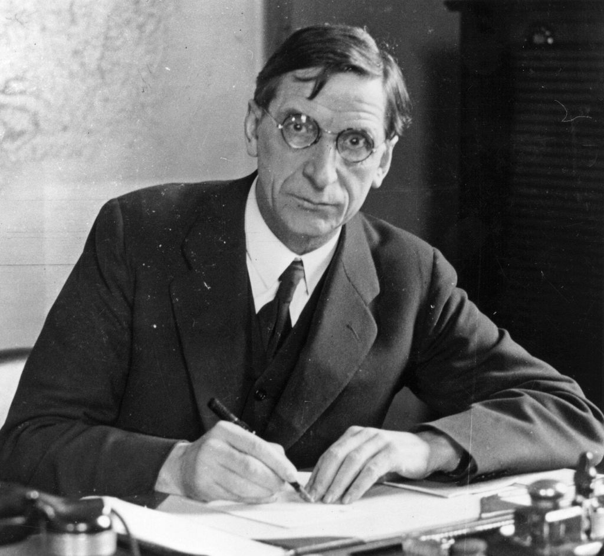

- Overall Party image.
  - leadership ability,
  - decision-making and
  - sentiment towards person

## Business Outcome

- Perception
- ex: Wuhan virus
- Reputation \(Vs.\) Reality

## Business Outcome

- Monitor response

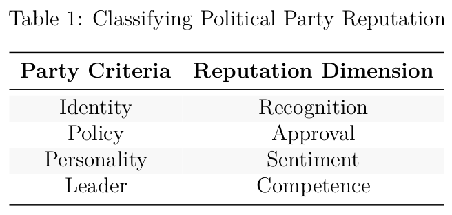

## Evaluating Business Success

[figure not shown]

- Reputation improves
- Reputation monitor
  - Awareness
  - Accurate assessment of attitude

## Evaluating Business Success

- Pilot System
  - Party Organisation
  - Well-connected Members

## Strategic Plan for Machine Learning Adoption

- Educate Executives
- Viability of a reputation monitor
  - Banking Sector
- Reputation monitor for Fianna Fáil
  - How Supervised Learning works

## Strategic Plan for Machine Learning Adoption

- Training Data
- Binary Classifier: ‘positive’ or ‘negative’
  - Confusion Matrix and ROC Curve
- Ranking based on probability estimates
- Benchmark
  - **Political Social Media Posts** dataset

## Machine Learning Readiness

- PySpark
- Pandas dataframes and Python libraries
- Further training

## Risk Management

[figure not shown]

- Limited Domain Knowledge
- Index to Rank Reputation
- Activists
  - high proportion of posts

## Risk Management

- Compiling Training Data
  - Banking: One researcher and two research assistants
- Non-response bias
- Emotive / Inflammatory posts
- Social Media Bias

## Review of SenTube: A Corpus for Sentiment Analysis

## Summary

- YouTube Posts
  - text categorisation
  - sentiment analysis
  - tablets and automobiles

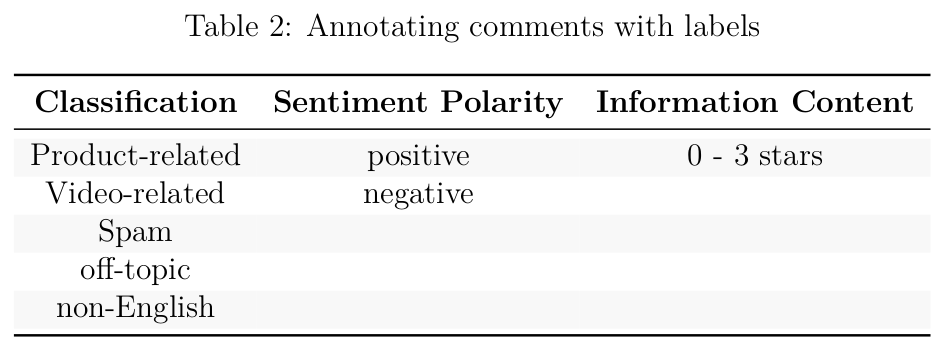

## Summary

- Twitter
- User Profile
- Single-document Labels

## Annotation Guidelines

- Accuracy and Consistency
  - fixed set of options
- Identity
  - no qualitative dimensions
    - attractiveness, convenience, durability

## Annotation Guidelines

- Standardisation
  - level of agreement
  - Krippendorff’s \(\alpha\) coefficient
  - Recommend > 0.8
- “a gold-standard sample”
- Single annotator
  - 208 videos and 36 thousand comments!

## Machine Learning Techniques

- Labeling
  - Supervised Learning
  - Bias \(Vs.\) Variance
- Baseline model
  - “bag-of-words”

## Machine Learning Techniques

- Multi-Class Classification
  - Product type
  - Comment and Sentiment
- Support Vector Machine
  - Linear Boundary

## Advantages

1. Stability
2. Discussions and Conversations
3. Template
4. Annotation guidelines
   - automatic labeling

## Disadvantages

1. Product Placement
2. Sentiment  
   - finer granularity
3. No ‘likes’ / ‘dislikes’